# A3: SPL Library Checkouts

### Introduction

The Seattle Public Library has been collecting data on the items checked out by customers for quite some time and in 2005 this data was released to the public. There is no customer information to be found in the data because privacy was of top priority. The only data to be gathered is item information, checkout month, and checkout year but this is enough to conduct the following analysis. I have chosen to analyze the number of fiction and non-fiction items checked out at least ten times in the past six years, four types of publications checked out at least ten times in the past six years, and the number of checkouts in the past decade for the top five greatest books.

I’m analyzing fiction and non-fiction items because I want to see what Seattle residents prefer and if the COVID pandemic changed these preferences. The four types of publications (Book, eBook, Audio book, and Magazine) are being analyzed because I wanted to see if there was a rise in digital items being checked out, especially during and after the pandemic. Finally, I’m curious to see the total number of checkouts for the top five greatest books of all time. I’m expecting there to be some sort of correlation between the rank of the book and the number of checkouts.

### Summary Information

I’ve chosen five values that relate to the following charts and to my personal reading history. In the past decade, there have been 29,743,074 items with fiction as the subject checked out and 5,347,119 items with non-fiction as the subject checked out. Based on these two values we can say that that for every non-fiction item checked out, six fiction items are checked out!

At the beginning of the year, I finished reading *The Hobbit* and I thought it was a good 8/10 so I decided to analyze this as my fiction item. In the past year, the Book and eBook versions of the *The Hobbit* have been checked out a total of 370 times. I was thinking that this could possibly be because of the new Lord of the Rings show on Amazon. Upon completing *The Hobbit*, I started reading *Lifespan: Why We Age and Why We Don’t Have To*. I haven’t finished it yet because I’ve been very busy this quarter but this type of book is what I usually read. In the past year, the Book and eBook versions of *Lifespan: Why We Age and Why We Don’t Have To* have been checked out a total of 597 times. Finally, I wanted to see how many times my favorite read of 2022 has been checked out in the past decade. *Sapiens: A Brief History of Humankind* was checked out a total of 24,823 times and I can see why! It is definitely one of my favorite books I’ve read.

### The Dataset

The data was collected and published by the Seattle Public Library. There are three smaller data sets that I used with the following conditions: all items checked out from 2022-2023, items checked out at least five times a month from 2013-2023, and items checked out at least ten times a month from 2017-2023. All data sets have multiple parameters but I only used/analyzed the following: MaterialType, CheckoutYear, CheckoutMonth, Checkouts, Title, Creator, and Subjects. I also added a date parameter to two of the data sets when analyzing trends. The data was collected from the monthly checkouts of Seattle Public Library customers. Privacy was the biggest concern when releasing the data so only the number of checkouts per item, checkout month, and checkout year were published to maintain the customers’ privacy. The Seattle Public Library has done a good job of maintaining this privacy that there no ethical questions come into consideration when working with the data. However, some limitations with the data include analyzing specific dates that items were checked out. Only the month and year were given so there is no way to analyze this data on a daily basis.

### First Trends Over Time Chart

This chart showcases the number of non-fiction to fiction checkouts in the past six years. I enjoy reading non-fiction but also read fiction if a book catches my attention. When I’m on the bus I tend to see people reading fiction books and I know that most people in Seattle have this preference. I wanted to analyze this and see how the number of non-fiction checkouts compared to fiction checkouts. Also, I wanted to see if the pandemic had any impact on the reading preferences of Seattle bookworms. The chart was designed to demonstrate the number of checkouts for fiction and non-fiction books over time. The x-axis is time in years for the past six years and the y-axis is the total number of checkouts throughout the year.

My observation was confirmed and the visualization shows that Seattle people read more fiction than non-fiction. To my surprise, the number of fiction checkouts rebounded by a greater amount than non-fiction once things began to reopen in the second half of 2020 and all of 2021. However, there was a small spike in the number of non-fiction checkouts in the middle of 2020 and the number of checkouts has been higher than pre-pandemic levels. All in all, Seattle bookworms read their usual fiction title but have shown more interest in non-fiction in recent years.

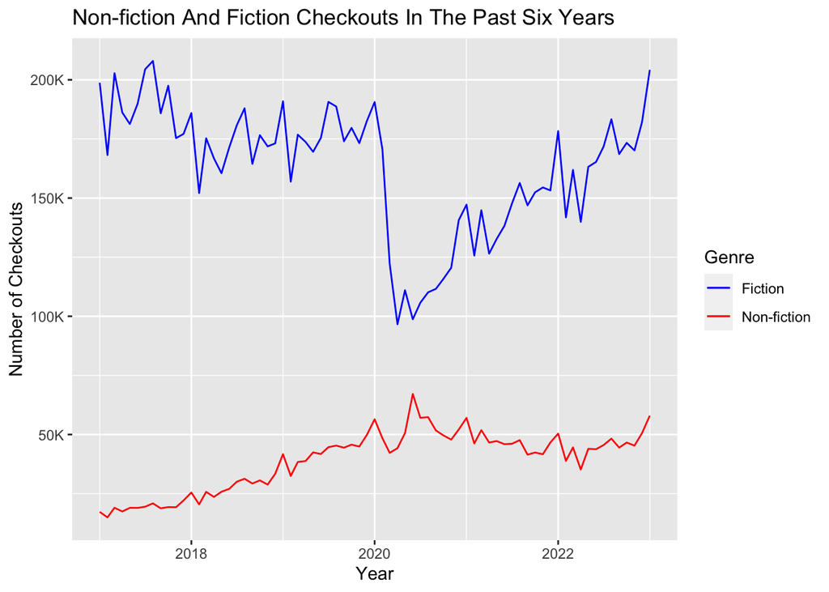

### Second Trends Over Time Chart

This chart showcases different types of publications (Book, eBook, Audio book, and Magazine) being checked out over the past six years. Based on my observation, I felt like the pandemic had made everything digital and I wanted to see if there was a sudden shift in the type of publications being checked out. The chart was designed to demonstrate the number of checkouts for select types of publications over time. The x-axis is time in years for the past six years and the y-axis is the total number of checkouts throughout the year.

Surprisingly, physical books have returned to their normal level and looks like it is only been increasing. Perhaps the pandemic had the opposite effect on some and only increased their preference on how to consume literature. However, the number of eBook and Audio book checkouts has been steadily increasing since which may or may not be due to the pandemic. An argument could be made that this was inevitable due to the convenience that they provide. One thing that surprised me was how the number of magazine checkouts suddenly stopped in 2019. I thought I had made a mistake but I could not find any data on it nor news article that covered what happened. I included this type to analyze if magazine checkouts had slowed or were declining and it looks like that may be the case.

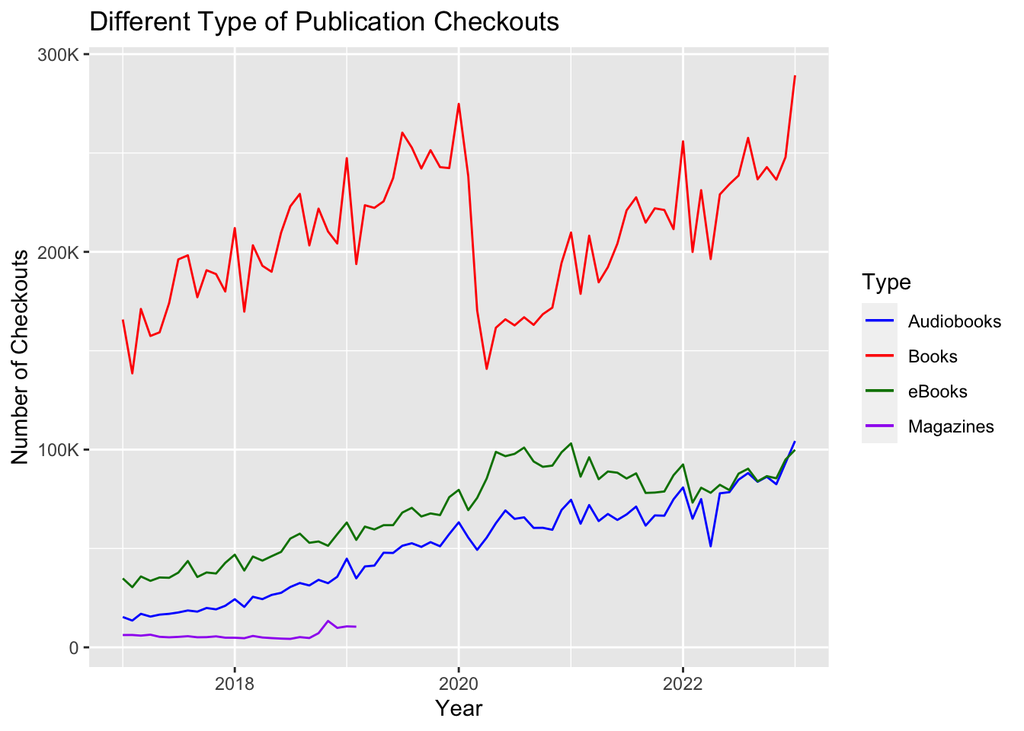

### Personal Choice Chart

For my last chart, I gathered what are considered to be the [top five greatest books](https://thegreatestbooks.org/) ever written and analyzed the number of checkouts over the past decade. I was curious to see whether the ranking of each book would correspond to its ranking on this chart (ex: if number 1 ranked book would have the most checkouts). The chart was designed to demonstrate the number of checkouts for each book but does not include time. The x-axis is the total number of checkouts in the past decade and the y-axis is the book being represented. Time is not displayed because I wanted to see the total number rather than checkouts over time.

I was very surprised to see that the number one ranked book, *In Search of Lost Time*, had the lowest number of checkouts by a wide margin. It makes sense because I personally had never heard of the book. The other books fell somewhere near their ranking on the list but it was interesting to see that *Ulysses* had nearly double the amount *Don Quixote* checkouts. Both of these books are large books that would take time to read and interpret so I was expecting a similar number of checkouts for both.

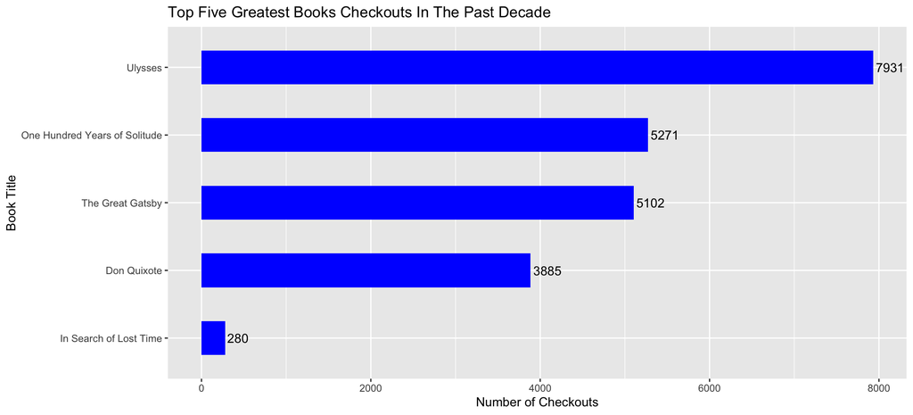